# Trends & Variations in Transportation Demand in Chicago

Amir Kazi

February 2019

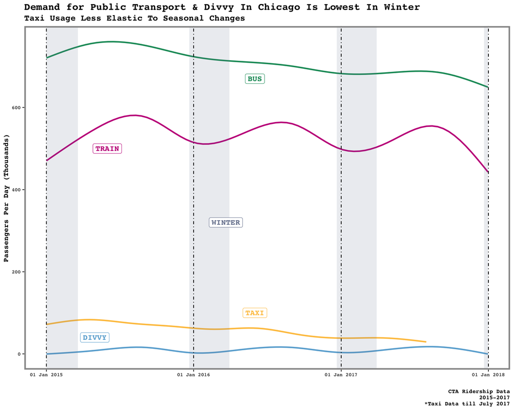

Between 2015 - 2017, there are two very clear trends: 1) For Trains & Divvy bikes, there is a prominent seasonal variation. In the summer, demand peaks, while in the winter, demand is at its lowest. 2) Demand for Buses & Taxis has decreased throughout this time period. There also doesn’t seem to be a seasonal component accompanying this decline. These patterns can impact the allocation and deployment of transportation services by the CTA across seasons. One possible explanation for the decline of demand for buses and taxis might be an increased reliance on ride-share services such as Uber, Lyft etc.

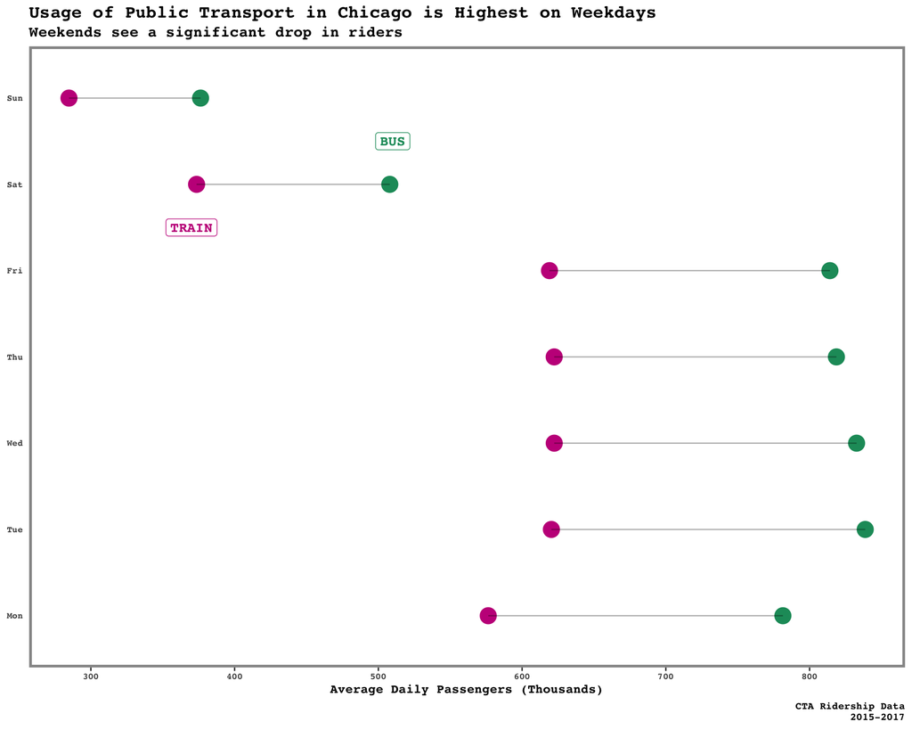

For buses and trains, comparisons within a week indicate that highest usage is during weekdays, possibly due to work or school transits. Deployments of public transportation are also more spread out on weekends by the CTA to ensure more efficient use.

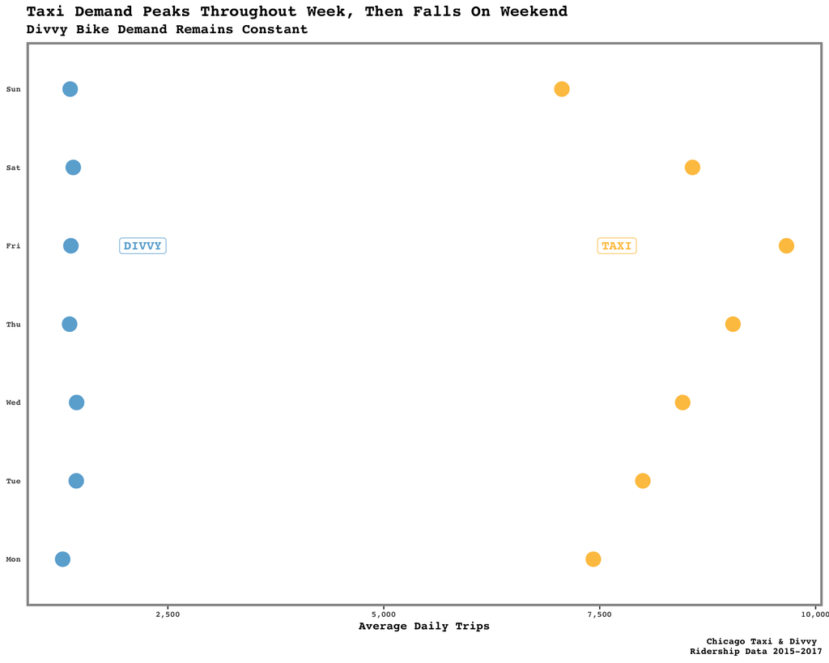

The first interesting observation is that demand for divvy doesn’t vary much throughout the week, even though one might expect weekends to have higher demand, especially in downtown areas. The second interesting observation is that demand for taxis keeps increasing between Monday - Thursday even though there isn’t any significant different in activities/behaviors of individuals between those days. Some of the increase in demand for Friday can be attributed to Friday-Night outgoing behavior. While weekends see a decline, Sunday is much lower than Saturday, which is also surprising.

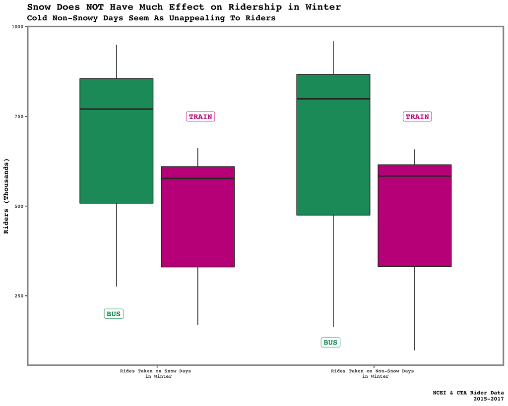

Comparing within cold days, it can be seen that consumers are indifferent between the presence & absence of snow. As such, snow doesn’t necessarily present a physical barrier that would make people want to take fewer buses or trains (on average).

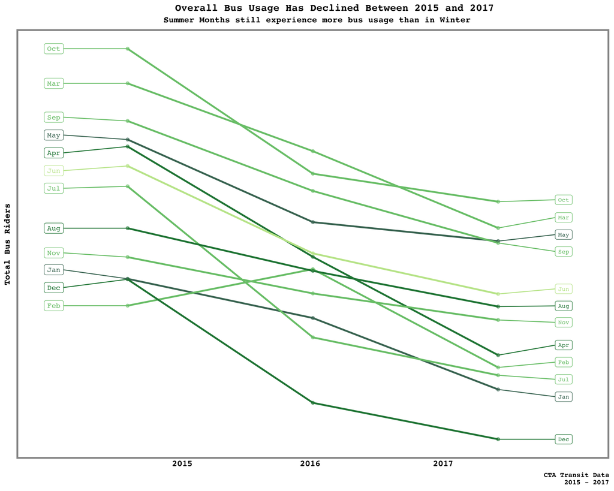

The demand for buses has been falling between 2015 and 2017 as established earlier. However, further exploration reveals that this decline isn’t driver by any particular set of months or seasonality, but by an overall decline across each month.

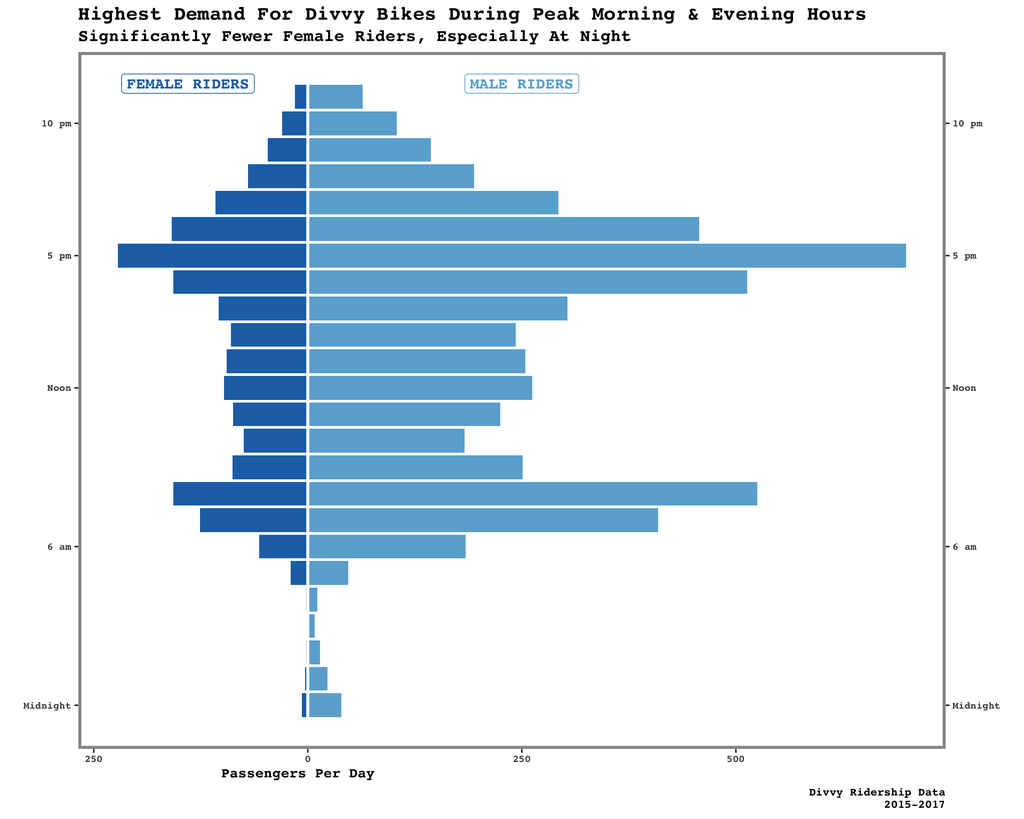

Demand for divvy bikes peaks at morning and evening rush hours. There is a noticably higher usage of divvy bikes by men compared to women at all hours of the day. It’s also interesting to note that there are almost no women riding bikes between 1 am and 4 am.

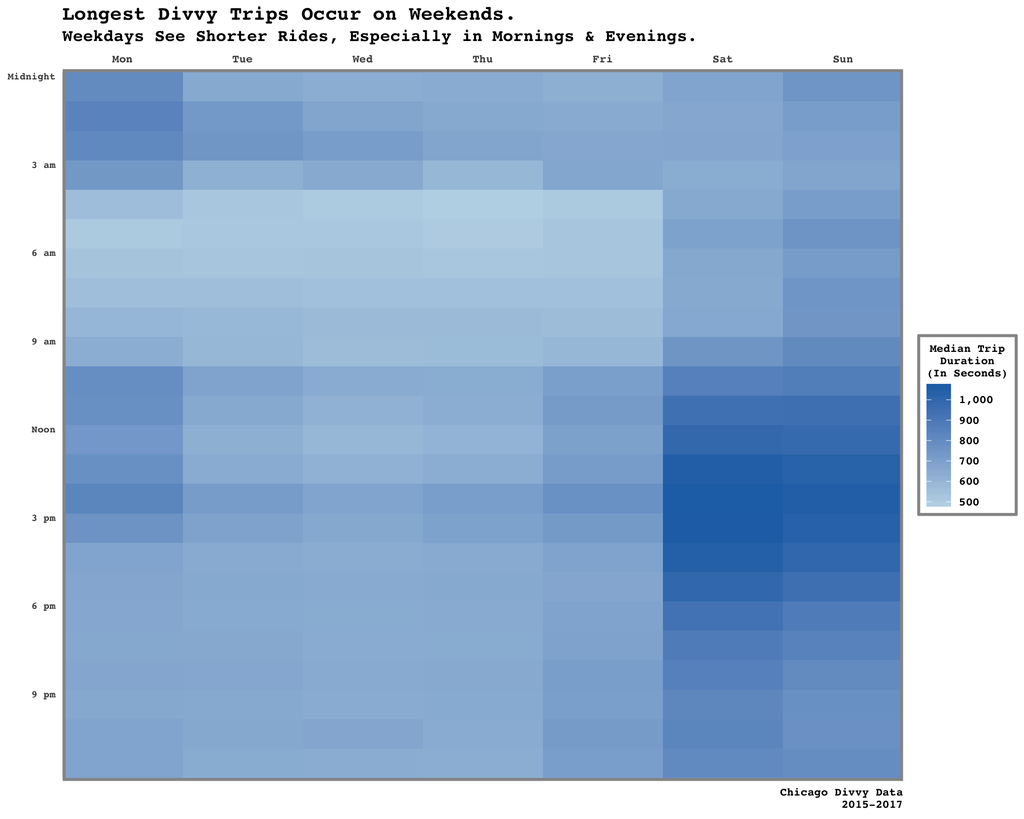

Possibly due to increased tourist and visitor usage in Downtown/River area on weekends, the median trip duration is quite large compared to weekday median trip durations. Late night trips also seem to be of large durations, which may most likely be attributed to a very low number of riders in the first place, who may be interested in travelling for long durations at that time of day.

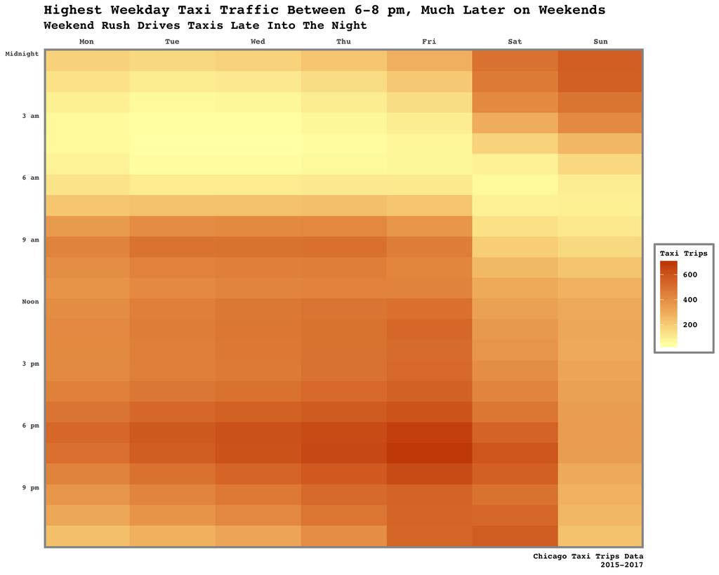

During weekdays, high demand is during the day, peaking during evening rush hour, with Friday evening rush hour being the busiest. However, unlike on weekdays, on weekdays, demand stays high at night, and extends to the early hours of the next day on Saturday and Sunday.

#### NEXT STEPS:

Next steps involve creating maps & vizualizations that highlight flow of traffic & changes in demand patterns & routes.